# β diversity among ant communities on fragmented habitat islands: the roles of species trait, phylogeny and abundance - Zhao - - Ecography - Wiley Online Library

[Ecography](https://onlinelibrary.wiley.com/journal/16000587)

[Early View](https://onlinelibrary.wiley.com/toc/16000587/0/0)

Research

Open Access

# β diversity among ant communities on fragmented habitat islands: the roles of species trait, phylogeny and abundance

[Yuhao Zhao](https://onlinelibrary.wiley.com/action/doSearch?ContribAuthorStored=Zhao%2C+Yuhao),

[Nathan J. Sanders](https://onlinelibrary.wiley.com/action/doSearch?ContribAuthorStored=Sanders%2C+Nathan+J),

[Juan Liu](https://onlinelibrary.wiley.com/action/doSearch?ContribAuthorStored=Liu%2C+Juan),

[Tinghao Jin](https://onlinelibrary.wiley.com/action/doSearch?ContribAuthorStored=Jin%2C+Tinghao),

[Haonan Zhou](https://onlinelibrary.wiley.com/action/doSearch?ContribAuthorStored=Zhou%2C+Haonan),

[Ruisen Lu](https://onlinelibrary.wiley.com/action/doSearch?ContribAuthorStored=Lu%2C+Ruisen),

[Ping Ding](https://onlinelibrary.wiley.com/action/doSearch?ContribAuthorStored=Ding%2C+Ping),

[Xingfeng Si](https://onlinelibrary.wiley.com/action/doSearch?ContribAuthorStored=Si%2C+Xingfeng),

First published: 27 August 2021

https://doi.org/10.1111/ecog.05723

## Abstract

Habitat loss and fragmentation reduce biodiversity and alter species composition in local communities. β diversity describes the variation in species composition between or among communities in fragmented landscapes and has two components: species turnover and nestedness. In this study, we assessed β diversity of ant assemblages on 24 island fragments in the Thousand Island Lake, China. We constructed a species-level phylogenetic tree and measured five morphological traits of all ant species captured. We then assessed taxonomic (both incidence-based and abundance-weighted), functional and phylogenetic β diversity and partitioned β diversity into turnover and nestedness (as well as the contributions of particular species and particular islands). Finally, we examined the relationships between β diversity and a suite of geographical variables (i.e. difference in island area, difference in isolation and inter-island distance) using Mantel tests. We found taxonomic and phylogenetic turnover components dominated overall β diversity whereas the functional turnover and nestedness components contributed equally to overall β diversity. Overall β diversity increased with increasing difference in isolation and inter-island distance; however, only abundance-weighted overall β diversity decreased with increasing difference in island size. Our results indicate that species that were abundant on large islands were also abundant on small islands. We conclude that the dispersal limitation of ants likely shapes the pattern of β diversity along isolation and inter-island distance gradients. Additionally, functional redundancy of species (i.e. different species share similar functional roles) could also explain β diversity patterns among fragmented habitat islands. Our results highlight the necessity of incorporating both incidence-based and abundance-weighted community data when examining β diversity in fragmented landscapes. By partitioning β diversity into the contributions of particular species and particular fragments, our study implies that small patches can be valuable for maintaining biodiversity among ant communities.

## Introduction

Human-induced landscape changes have reduced biodiversity and reshaped the composition of communities (Díaz et al. 2019, Nogué et al. 2021). Among habitat alterations induced by anthropogenic activities, habitat loss and fragmentation are one of the greatest threats to biodiversity conservation (Wilcove et al. 1998, Haddad et al. 2015, Liu et al. 2019a). Thus, it is critical to understand the underlying processes that structure ecological communities in fragmented landscapes.

β diversity describes the variation in species composition among sites and has been used to investigate potential mechanisms of community assembly (Kraft et al. 2011, Bishop et al. 2015, Gómez-Rodríguez and Baselga 2018, García-Navas et al. 2020). β diversity is comprised of two components: variation in composition determined by species replacement (i.e. turnover) and nestedness (Baselga 2010, Legendre 2014). Turnover occurs when existing species are replaced by different ones at new sites, whereas nestedness occurs when species found in species-poor communities are also found in increasingly species-rich communities (Baselga 2010). Although the turnover and nestedness components both contribute to β diversity, their relative importance depends on the processes structuring communities. For example, if environmental conditions vary among patches, and species are adapted for particular conditions, the turnover component of β diversity is more likely to shape community composition perhaps via niche filtering. Additionally, spatial and historical constraints can also lead to turnover (Qian et al. 2005). The nestedness component, on the other hand, tends to be the most common pattern due to a number of processes such as selective colonization, selective extinction, nestedness of habitats or passive sampling (Wang et al. 2010). Notably, patch size and isolation (i.e. distance to the nearest shore of the mainland) are widely considered to be essential factors determining β diversity patterns in fragments or on habitat islands (Dapporto et al. 2014, Matthews et al. 2015, Si et al. 2016, Edge et al. 2017). Additionally, as the distance between two fragments increases, β diversity should also increase, which is known as the distance-decay effect (Baselga and Gómez-Rodríguez 2021). Therefore, analysing the relationship between β diversity (and its components) and geographical variables (e.g. differences in fragment area and isolation, and geographical distance) can provide a better understanding of community assembly in fragmented landscapes (Fattorini 2010, Wu et al. 2017).

Furthermore, conservation scientists are increasingly incorporating β diversity when providing practical conservation strategies (Angeler 2013, Socolar et al. 2016). For instance, if β diversity is mainly dominated by species replacement, all patches should be of similar conservation value because they all have relatively unique species compositions (Baselga 2010, Angeler 2013). Conversely, if nestedness is more common, sites with higher species richness (which are usually the larger patches in fragmented landscapes) should receive higher conservation priority. Moreover, when turnover shapes β diversity across various taxa or ecosystems, it can be difficult to infer which specific sites or species contribute the most in shaping regional β diversity. By adopting the total variance of community data as an estimate of β diversity, Legendre and De Cáceres (2013) proposed a new approach, which allows for partitioning β diversity into local contributions to β diversity (LCBD) and species contributions to β diversity (SCBD). LCBD and SCBD indicate, respectively, how unique sites and species are in a set of communities. As a result, sites and species that contributed more to the regional β diversity should have higher conservation priorities (Legendre and De Cáceres 2013, Hill et al. 2021).

In studies of β diversity, traditional taxonomic metrics may be not sufficient to undercover the ecological processes shaping variation in community composition among fragments. Functional and phylogenetic diversity, which account for ecological differences among species, can provide additional insights into community assembly (Swenson 2014, Cadotte et al. 2019, Jarzyna et al. 2021). For example, hummingbird assemblages in the Andes have high taxonomic β diversity but low phylogenetic and functional β diversity, indicating the roles of geographic barriers in isolating lineages in similar environments (Weinstein et al. 2014). By expanding Legendre and De Cáceres (2013)'s β diversity partitioning framework to functional and phylogenetic perspectives, Nakamura et al. (2020) also found a mismatch among taxonomic, functional and phylogenetic β diversity of stream fish communities. Namely, they found that the variation in species composition, not the distribution of clades and functional traits, plays a significant role in explaining the variation of stream fish community composition (Nakamura et al. 2020).

Apart from the importance of different dimensions of diversity, another important issue in β diversity is whether incidence-based (i.e. only presence or absence of species) or abundance-weighted measures are used (Anderson et al. 2011, Baselga 2013). Incidence-based approaches consider only the identities of species (with an emphasis on rare species), whereas abundance-weighted approaches are more information-rich (and emphasize on common and numerically dominant species) (Anderson et al. 2011). In fragmented areas, small patches generally support few species, but the average abundance of each species on small islands (or fragments) may be higher than that on larger islands due to disturbance (Ibanez et al. 2020). Thus, while it is relatively straightforward to predict how the number of species varies with area and isolation (MacArthur and Wilson 1967), predicting the relationship between the relative abundance of species and island variables (area and isolation) is somewhat more challenging. Research that examines how habitat fragmentation affects both incidence-based and abundance-weighted β diversity simultaneously is still lacking, especially when abundance data are difficult to obtain.

Ants are an ideal taxon for assessing biodiversity patterns in fragmented habitats because they are sensitive to changes in habitat (Andersen 2019). They are also diverse and abundant (Hölldobler and Wilson 1990) and play a wide range of ecological roles (Tuma et al. 2020). Although a number of studies have examined the effect of habitat fragmentation on ant community composition (Crist 2009, Leal et al. 2012, Cuissi et al. 2015), to date, no studies have examined β diversity patterns of ant communities among different patches through multiple dimensions of diversity by incorporating abundance of community members simultaneously.

Studies in fragmented habitats have tested the contributions of various factors on patterns of β diversity. However, these factors are confounded by joint effects of historical events, multiple source pools, fragment age, climate and human disturbance (Fattorini 2010). The fragmented habitat islands surrounded by water (or land-bridge islands created by hydroelectric damming), such as the islands in the Thousand Island Lake (TIL) of eastern China, are often immune to some of the confounding factors (Wilson et al. 2016). Specifically, land-bridge islands in TIL region are typically biologically simple, relatively small, the same age (62 years), and easily accessed for repeated sampling (Diamond 2001, Dapporto et al. 2014).

In this study, we applied multi-component (taxonomic [considering both incidence-based and abundance-weighted data], functional and phylogenetic diversity) and multi-partitioning approaches of β diversity to assess the distribution of ant assemblages on 24 subtropical land-bridge islands in the Thousand Island Lake, China. Specifically, we aim to examine: a) the relative importance of species replacement (turnover) and nestedness components on the overall patterns of β diversity; b) which geographical variables (e.g. island area, isolation or inter-island distance in this study) shape the patterns of β diversity; and c) the relative contributions of different species and sites to β diversity. We end by suggesting how our results from β diversity partitioning can inform conservation decisions.

## Material and methods

### Study area

This study was carried out in a land-bridge island system, the Thousand Island Lake (29°22'–29°50' N, 118°34'–119°15' E) in Zhejiang Province, eastern China. The lake was formed by dam construction in 1959. The flooded area is approximately 580 km<sup>2</sup> and includes more than 1000 islands. Forests were clear-cut on these islands in 1959, and thus succession on each island was initiated from similar starting conditions (Liu et al. 2019b). Owing to the strict protection policy since the 1980s, subsequent human disturbance is low or nonexistent on most of islands. The major vegetation type is now secondary successional forest dominated by Masson pine *Pinus massoniana* (Liu et al. 2020). The region is in the subtropical zone and has a typical subtropical monsoon climate with significant seasonal changes (i.e. hot, wet summer and cool, dry winter) (Si et al. 2014).

### Ant sampling, trait data and phylogeny construction

Twenty-four islands were selected in this study that cover a wide range of island area and isolation (Fig. 1). Island area, isolation (measured as the shortest shore-to-shore distance to the mainland) and inter-island distance (measured as shortest shore-to-shore distance between two islands) were calculated in ArcGIS 10.4 (<https://support.esri.com/zh-cn/products/desktop/arcgis-desktop/arcmap/10-4-1>) when water level reaches 100 m a.s.l. Notably, our study was conducted at a relatively small spatial scale (ca 500 km<sup>2</sup>) (Fig. 1). Thus, the variation in abiotic/biotic environment among islands (i.e. climate) is negligible compared with the geographical variables (i.e. island area, isolation and inter-island distance). Additionally, island area is a good surrogate for the habitat heterogeneity within each island at the patch scale (i.e. larger islands tend to harbour more diverse micro-habitats than do smaller islands) (Si et al. 2017).

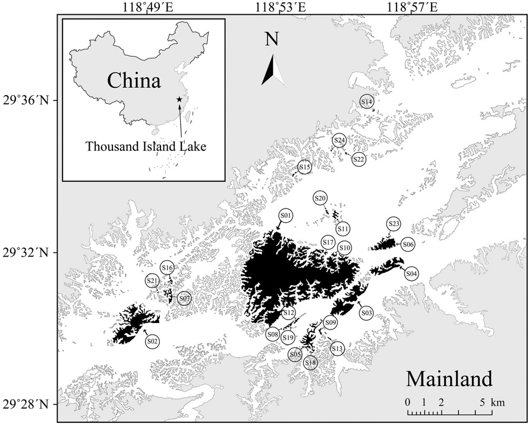

**Figure 1**

The 24 study islands (in black) in the Thousand Island Lake region, Zhejiang, China (modified from Si et al. 2014)..

We used pitfall traps to capture ant species on study islands in May and August 2017. Before sampling, we set up transects on study islands, with the length up to 200 m on large islands and < 200 m on small islands. The transect was laid parallel to the longest axis of the island (see more details about field sampling in Zhao et al. 2020). We then placed the pitfall traps along each transect (see Supporting information for the number of pitfall traps on each island). Each trap had a volume of 180 ml (diameter = 62 mm, depth = 77 mm) and was covered by a rain guard to prevent flooding. A solution of ethanol and propylene glycol (1:1, ca 40 ml) was used to preserve ant specimens caught in the traps. This solution neither attracts nor repels ants (Abensperg-Traun and Steven 1995). To avoid digging-in effects, we left each trap open for at least seven days before sampling (Greenslade 1973). During each sampling period, traps were opened for five consecutive nights and checked every two or three days to avoid overfilling. The individuals captured in each trap were counted and identified to at least morphospecies level with the help of local ant experts.

We sequenced three nuclear genes (18S, 28S and wingless) to construct ant phylogeny and measured five morphological traits (Weber's length, relative eye width, relative leg length, relative mandible length and relative scape length; Supporting information) of all ant species captured on study islands to estimate phylogenetic and functional diversity (see Supporting information for more information on phylogenetic tree construction and functional trait measurement). The original trait data were standardized with a mean of zero and a standard deviation of one and transformed into a Euclidean distance matrix. We then used principal coordinate analysis (PCoA) to reduce the dimensionality of the original functional matrix. The first three PCoA axes were used to calculate functional β diversity, which accounted for 89% of all functional variability (Supporting information).

### Statistical analyses

#### Testing sampling completeness

We used the frequency data (i.e. the number of times that a species was captured in the pitfall traps) to test sampling completeness on all islands using the *iNEXT* function in the R package ‘iNEXT' (Hsieh et al. 2016). We combined the pitfall trap data collected in both May and August, and used rarefaction methods to control for the effects of variation in sampling efforts on each island. In this study, the minimum number of pitfall traps among all islands was 12. We thus randomly sampled 12 pitfall traps 100 times for each island that had more than 12 pitfall traps. We then carried out the following β diversity analyses based on the rarefied results and reported the mean values after 100 re-samplings.

In addition, we tested the sensitivity of using particular abundance values (maximum abundance versus mean abundance across the survey for each island) and the scaling methods of relative abundance of ants on study islands. The results were qualitatively identical when we used different methods, so we report only the maximum abundance recorded from two months and scaled abundance values (see details about the estimates of abundance in the Supporting information).

#### β diversity partitioning: turnover and nestedness components

For the separation of species replacement and nestedness components from taxonomic, functional and phylogenetic overall β diversity, we used the pairwise dissimilarity partitioning approaches proposed by Baselga (2010, 2012). Following this approach, the Sørensen dissimilarity index, a measure of overall β diversity (i.e. βsor), was decomposed into two additive components: a) a spatial turnover component (without the effect of species richness variation), obtained by applying the Simpson dissimilarity index (i.e. βsim) and b) a nestedness component (i.e. βsne), calculated by the difference between βsor and βsim.

Abundance-weighted overall β diversity (i.e. βbray) was also decomposed into two components: balanced variation in abundance (i.e. βbal; whereby the individuals of some species at one site are replaced by the same number of individuals of different species at another site) and abundance gradients (i.e. βgra; whereby some individuals are lost from one site to the other), following the partitioning of Bray–Curtis dissimilarity index proposed by Baselga (2013). The abundance framework is analogous to the partition of β diversity into spatial turnover and nestedness components. Thus, βbal and βgra can represent abundance turnover and abundance nestedness, respectively (Loiseau et al. 2017).

Pairwise dissimilarity tends to have a large variation, suggesting that the average of pairwise dissimilarity measures may not properly quantify multiple-site compositional heterogeneity (Wu et al. 2017). To determine the relative importance of turnover and nestedness components on overall β diversity, we thus used multiple-site partitioning approaches also proposed by Baselga (2010, 2012). To distinguish from the pairwise dissimilarity measures, we used capital letters to represent multiple-site β diversity (e.g. βSOR for multiple-site overall β diversity). The ratio between βSIM (or βBAL) and βSOR (or βBRAY) obtained from multiple-island dissimilarity indicates the relative contribution of the turnover component in island ant assemblages. Here we chose only 10 random islands to calculate functional multiple-site β ratio due to the computational constrains (see notes in the function *functional.beta.multi*). Pairwise and multiple-site dissimilarity partitioning frameworks were performed in R using ‘betapart' package (Baselga et al. 2021).

#### β dDiversity partitioning: species and local contributions

To understand the contributions of particular species and particular island components of β diversity, we used the partitioning method proposed by Legendre and De Caceres (2013) and Nakamura et al. (2020). The partition of taxonomic (both incidence-based and abundance-weighted) β diversity was calculated using *beta.div* function in ‘adespatial' package (Legendre and De Cáceres 2013). This method first calculates the total variation of the community matrix as β diversity (hereafter BD for results based on incidence-based community, and A-BD for results based on abundance-weighted community), and then the BD can be partitioned into species contribution (SCBD: degree of variation of individual species across the study area) and local contribution (LCBD: comparative indicators of the ecological uniqueness of the sites). Similarly, we used A-SCBD and A-LCBD to represent the results based on abundance-weighted community.

The method used for partitioning of functional and phylogenetic β diversity was developed by Nakamura et al. (2020). Nakamura et al. (2020) expanded the BD framework to obtain functional and phylogenetic dimensions of diversity, namely BDfun and BDphy. Accordingly, the BDfun and BDphy can be partitioned into species (XSCBD for BDfun and PSCBD for BDphy) and local (XLCBD for BDfun and PLCBD for BDphy) contribution. Code is available on Zenodo: <https://doi.org/10.5281/zenodo.3817980> (Nakamura et al. 2020).

#### Geographical drivers

We used Mantel tests with Spearman's method to examine the correlation of overall β diversity and its components against geographical variables (difference in island area, difference in isolation and inter-island distance). The partial Mantel tests were used to remove the effect of covariation because an inter-correlation between matrices of difference in island area and inter-island distance was detected (Spearman's Mantel test: ρ = −0.168, p = 0.042). Additionally, we used multiple linear regression models to test the relationships between local contribution and island variables (area and isolation).

## Results

A total of 74 species belonging to 36 genera and seven subfamilies were captured, including 62 species in May and 62 species in August. Ant communities on all islands were sampled sufficiently with high sampling completeness both in May (77–100%) and August (88.1–99.3%) (Supporting information). After combining the data from May and August, species richness ranged from 8 to 47 species per island, with a mean value of 22.6 species.

### Turnover and nestedness components in taxonomic (both incidence-based and abundance-weighted), functional and phylogenetic β diversity

Taxonomic (incidence-based and abundance-weighted), functional and phylogenetic overall β diversity (βsor and βbray) of ant communities were all positively correlated with difference in isolation and inter-island distance; these relationships were all statistically significant except for the relationship between functional βsor and inter-island distance (Fig. 2, Table 1). For the turnover (βsim and βbal) and nestedness (βsne and βgra) components, taxonomic βsim was positively corelated with inter-island distance whereas taxonomic βsne was positively corelated with difference in isolation (Fig. 2, Table 1). Functional βsim was positively associated with both difference in isolation and inter-island distance (Fig. 2, Table 1). Phylogenetic βsim was only positively associated with inter-island distance. However, among all β diversity indices, only abundance-weighted overall β diversity (βbray) was negatively affected by differences in island area (Fig. 2, Table 1).

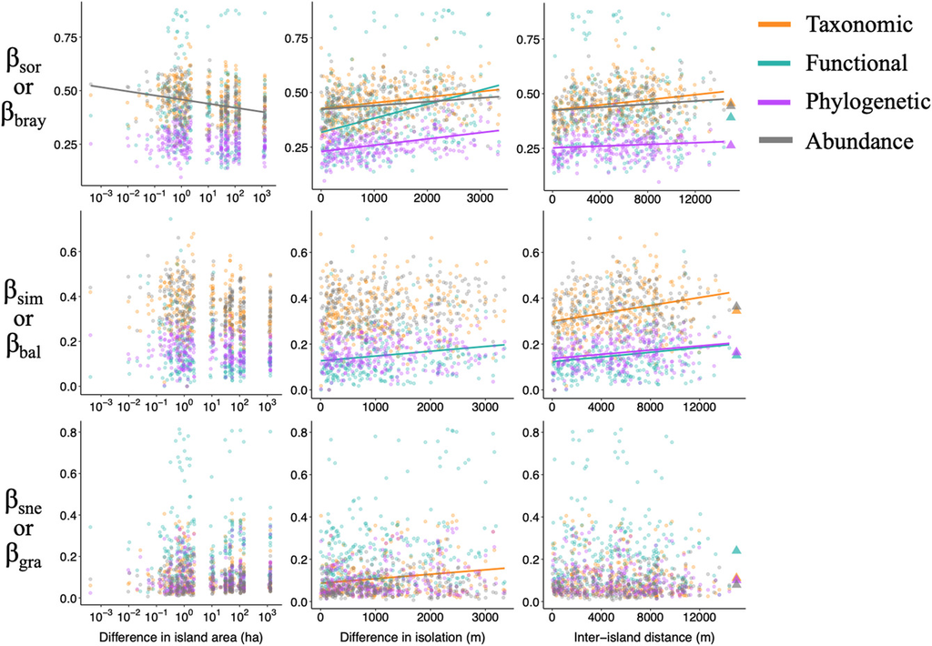

**Figure 2**

The relationships between taxonomic (incidence-based and abundance-weighted), phylogenetic and functional pairwise β diversity (βsor and βbray) and its spatial turnover (βsim and βbal) and nestedness (βsne and βgra) components of ant communities on 24 islands in the Thousand Island Lake, China and geographical variables (difference in island area [ha], difference in isolation [m] and inter-island distance [m]). Lines represent significant relationship based on (partial) Mantel tests (Table 1). The triangles embedded in the right side of the figure represent the mean values of each pairwise β diversity.

Table 1. Results of (partial) Mantel tests between taxonomic (both incidence-based and abundance-weighted), functional and phylogenetic pairwise β diversity (βsor and βbray) and its spatial turnover (βsim and βbal) and nestedness (βsne and βgra) components of ant communities on 24 islands in the Thousand Island Lake, China and geographical variables (difference in island area, difference in isolation and inter-island distance). Significance levels: p < 0.1, *p < 0.05, **p < 0.01, ***p < 0.001

| Component | Dissimilarity index | Difference in island area (control for difference in isolation) | Difference in isolation (control for difference in area) | Inter-island distance |
| --- | --- | --- | --- | --- |
| Taxonomic | βsor | −0.090 | 0.248** | 0.264** |
|  | βsim | −0.164 | 0.016 | 0.278** |
|  | βsne | 0.093 | 0.169* | −0.103 |
| Functional | βsor | −0.133 | 0.254* | 0.071 |
|  | βsim | −0.141 | 0.231* | 0.178* |
|  | βsne | 0.052 | 0.098 | −0.062 |
| Phylogenetic | βsor | −0.011 | 0.366*** | 0.176* |
|  | βsim | −0.095 | 0.128 | 0.246** |
|  | βsne | 0.103 | 0.130 | −0.127 |
| Abundance | βbray | −0.274** | 0.171* | 0.154* |
|  | βbal | −0.163 | 0.063 | 0.103 |
|  | βgra | −0.054 | 0.126 | 0.050 |

The turnover (βSIM and βBAL) component of β diversity dominated the taxonomic (both incidence-based and abundance-weighted) and phylogenetic multiple-site overall β diversity (i.e. βratio > 0.5, Fig. 3). However, nestedness and turnover components contributed equally to functional multiple-site overall β diversity (βratio = 0.52, Fig. 3). The values of taxonomic and abundance-weighted pairwise turnover components were typically larger than functional and phylogenetic ones, while the values of functional nestedness components were typically larger than the three other nestedness components (Fig. 2).

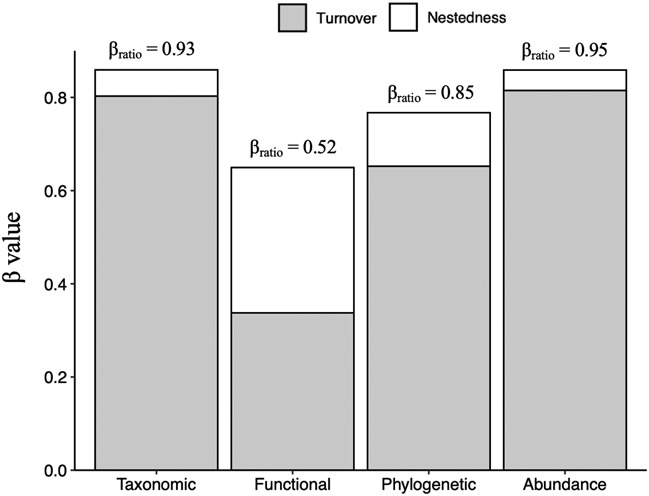

**Figure 3**

The relative contributions of spatial turnover (βSIM) and nestedness (βSNE) components of total taxonomic (both incidence-based and abundance-weighted), functional and phylogenetic β diversity (βSOR and βBRAY) among 24 study islands (10 islands for functional β diversity, see Material and methods for more details) in the Thousand Island Lake. The βratio was the ratio between the value of turnover and the value of overall multiple-site β diversity.

### Species and local contributions to taxonomic (both incidence-based and abundance-weighted), functional and phylogenetic β diversity

BD, A-BD, BD<sub>fun</sub> and BD<sub>phy</sub> represented values of 0.445, 0.219, 0.003 and 0.021 for ant community, respectively. The contribution of local communities ranged from 0.028 (2.8% of total variation) to 0.054 (5.4% total variation) for LCBD, 0.016 to 0.081 for A-LCBD, 0.009 to 0.300 for XLCBD and 0.014 to 0.162 for PLCBD, respectively (Supporting information). Notably, for A-LCBD, XLCBD and PLCBD, the site that contributed the most was island S22. This island contains 16 species belonging to 14 genera; two of them are relatively rare (*Iridomyrmex anceps* and *Ochetellus glaber*) and occurred on only Islands S22 and S16.

All local contributions had negative relationships with island area and positive relationships with isolation. Among them, the LCBD and A-LCBD increased significantly as area decreased (Table 2), indicating that smaller islands had slightly more unique communities than did larger islands. Species contributions varied among SCBD, A-SCBD, XSCBD and PSCBD (Supporting information). The most important species contributing to β diversity in local communities always varied. For SCBD, the most important species was *Nylanderia flavipes*, a species that occurred on 19 of 24 study islands. For A-SCBD, the most important species is *Pheidole* sp1, also a widespread species with relatively high abundance (Supporting information); For XSCBD, the most important species were all from the genus *Camponotus*, which are the largest ant species in our study islands. As for PSCBD, *Aenictus laeviceps* was identified as having the biggest contribution(Supporting information).

Table 2. Results of the multiple linear regression models between local contribution and island variables (scaled). Significance levels: p < 0.1, *p < 0.05, **p < 0.01, ***p < 0.001

[output not shown]

## Discussion

In this study, we assessed taxonomic, functional and phylogenetic β diversity of ant communities using two partitioning frameworks (species replacement and nestedness components as well as species and local site contributions) based on incidence-based and abundance-weighted community data on fragmented habitat islands in a large artificial reservoir. We found that the species replacement component dominated taxonomic (both incidence-based and abundance-weighted) and phylogenetic β diversity, whereas both replacement and nestedness components contributed similarly to functional β diversity. In the composition of island ant communities, islands with similar size showed a higher faunistic dissimilarity, while islands with similar isolation and closer to each other were more similar. Partitioning of β diversity into species and local site contributions revealed that smaller islands tended to contribute more to β diversity, whereas the contribution of particular species varied among taxonomic, functional and phylogenetic dimensions.

### Species replacement and nestedness components in taxonomic (incidence-based and abundance-weighted), functional and phylogenetic β diversity

Our results suggested that the turnover component is more important than the net loss of species for changes in the community composition of ants among island fragments in our lake system, showing a similar trend for abundance-weighted indices. This pattern is consistent with previous findings on breeding birds, lizards (Si et al. 2015) and spiders (Wu et al. 2017) from the same study system. Some ant species occurred on only a handful of islands: 15 species were endemic to single islands. This pattern could be often driven by a sampling effect, as studies have shown that short-term assessments tend to magnify taxonomic turnover component because of randomly undetected species on each island whereas long-term (i.e. decades) observation might have a better chance to observe a higher ratio of nestedness component (Dapporto et al. 2014). However, our results showed the sampling effects are likely to be weak in this study because all islands were almost completely sampled in both sampling periods (Supporting information). Instead, we think that stochastic processes driven by spatial constraints could result in high turnover (and endemism) (Qian et al. 2005), because ant species simply could not overcome the water matrix (this has also been verified with the effects of isolation and inter-island distance on β diversity, see Discussion below).

The phylogenetic turnover component also dominated the overall β diversity, indicating species turnover occurs in lineages with distant phylogenies (Graham and Fine 2008, Du et al. 2021). For example, comparing to other genus, species from the genus *Aenictus* occupy a relatively distant lineage that occurred on only several large islands (e.g. Islands S01, S03 and S05). In addition, our previous research found that the phylogenetic structure of ant communities on these islands tended to be clustered (Zhao et al. 2020). This means ants on different islands are more closely related than expected by chance, suggesting the possibility that distantly related lineages occupy different islands. In contrast, we found functional turnover component contributed to only half of the overall multiple-site β diversity (note that we used only 10 islands to calculate the functional multiple-site dissimilarity due to computational constrains. However, it can also be inferred from pairwise β diversity that the functional nestedness component was relatively high compared to taxonomic and phylogenetic β diversity, i.e. Fig. 2), which means the nestedness component was also important in functional β diversity. This result suggested that there is, to some extent, an ordered loss of ants' functional roles on study islands. Patch area has been verified to drive functional nestedness component because of the area-dependent extinction in fragmented habitats (Matthews et al. 2015), and isolation has also been revealed to affect functional nestedness component (Bender et al. 2017). However, we did not find a significant relationship between geographical variables and functional nestedness component in our study (see below). Additionally, the turnover of functional β diversity also indicated functional redundancy among ant communities (Ricotta et al. 2020): that is, different islands contain some species with similar morphological traits (e.g. body size and leg length) that may occupy similar niches. However, their relative abundance differed with island area (Fig. 2).

In this study, the greater the difference in distance to the nearest mainland between the two islands, the more dissimilar their communities were (Table 1, Fig. 2). The same pattern was also found in functional turnover and taxonomic nestedness components of β diversity (Table 1, Fig. 2). Our findings contrast with results from previous work in this system, where difference in isolation did not influence the taxonomic β diversity of breeding birds (Si et al. 2015). We also found that the farther the two islands are, the more dissimilar they are both in overall β diversity and turnover component. Taken together, these patterns could be explained by dispersal limitation: unlike birds, it may be more difficult for most ants to disperse from the mainland to islands (Badano et al. 2005), and even among islands (Morrison 2016). Because ants are social insects, only the queens can potentially disperse to other island fragments via mating flights (Helms 2018). Studies have shown that some species experience reproduction-dispersal trade-offs (Helms and Kaspari 2015), as some queens have higher nutrient loads at the expense of flight or dispersal (e.g. species in genus *Camponotus*). So, after a dispersal event of even a short distance, the ability of a queen to find a suitable nest site can be highly reduced. In addition, recent studies on butterflies and beetles – ants may have an intermediate dispersal ability between them – indicated that even short distances between islands and even intra-island barriers can prevent dispersal and gene flow (Salces-Castellano et al. 2020, Scalercio et al. 2020, Salces-Castellano et al. 2021). Thus, poor dispersers from the mainland might not reach remote islands, producing distance decay in β diversity as distance to nearest mainland increases. However, in this light, further research is needed to incorporate the dispersal-related traits of ants (i.e. body mass and flight muscle mass) (Helms and Kaspari 2015) to verify the dispersal limitation of ants among our study islands (Gómez-Rodríguez et al. 2015). Alternatively, we cannot rule out that the species we detected on the islands are the descendants of remnant species on mountaintops before the lake was formed. The study islands may still be experiencing species relaxation associated with species persistence and local extinction (Si et al. 2014, Jones et al. 2016). And the local extinction of ant species would be a joint effect of both deterministic and stochastic processes (Ning et al. 2019); however, we believe that the former may be the dominant process (Zhao et al. 2020).

Considering that island area is a more important factor in influencing α diversity than is isolation (Zhao et al. 2020), the lack of influence of island area on ant (incidence-based) β diversity is unexpected. This is probably because of the existence of different rare species on different islands that causes a similar level of compositional differences along the area gradient. However, after considering the relative abundance of ants, we found that the greater the difference in island area, the more similar communities were (Fig. 2). This result indicated that ant species on large and small islands have similar rank-abundances (i.e. the common species on large islands may be also the common one on small islands). However, the underlying mechanism behind this pattern could be complicated. In our lake system, the areas of each habitat may vary along island size (Chase et al. 2019), which results in the population of same ant species differing among islands (e.g. the relative abundance of *Pheidole nodus* on all islands varied from 23.41 [Island S17] to 52.96 [Island S21], Supporting information), and thus causing the unbalanced abundance differences along the island area gradient. On the other hand, even though species richness decreased with decreasing island area, the relative abundances of species on small islands were similar to those on large islands (e.g. *P. nodus* and *Brachyponera chinensis*, Supporting information). Such a pattern could be driven by the effects of generalist species: generalists tend to have broad niches, which allow them to persist and become abundant on small islands (Harvey and MacDougall 2014). Meanwhile, generalist species are also abundant on large islands because of the adequate amount of habitats on large islands (Fahrig 2017), thus, leading to the reduction of the abundance difference between large and small islands. Overall, the results of abundance-weighted community data illustrated that when partitioning β diversity, it is important to consider species abundance as it can point toward perhaps different mechanisms operating (Barwell et al. 2015).

In this study, we tested the effects of island area and isolation on patterns of β diversity in ants. Although we assume that habitats on the surrounding mainland are homogeneous, they can be heterogeneous at small scales, and thus influence the potential source pools for each island with different degrees of isolation. Moreover, all islands have experienced clear-cutting at the same time in our study area, but the larger islands tend to be at the later stage of succession while small islands are still at the earlier stage of succession after 60 years of inundation (Liu et al. 2019b). As a result, the stage of successions may potentially affect the species distribution among islands. Further investigations are thus needed to incorporate those considerations to better understand community compositions.

### Species and local contributions to taxonomic, functional and phylogenetic β diversity

Through the calculation of BD, A-BD, BD<sub>fun</sub> and BD<sub>phy</sub>, we found that the variation in ant community composition on study islands is mainly due to the variation in species composition, because of the significantly higher value of BD (and A-BD) than BD<sub>fun</sub> and BD<sub>phy</sub>. These taxonomically distinct species on the study islands may possess similar functions and/or share similar evolutionary histories, a phenomenon of functional or phylogenetic redundancy (Ricotta et al. 2020). Our findings are consistent with the fish metacommunity in Ivinhema River Basin where also the BD has a significantly higher value than BD<sub>fun</sub> and BD<sub>phy</sub> (Nakamura et al. 2020).

As for the contribution of site, we found small islands tended to contribute more to the BD and A-BD (i.e. LCBD and A-LCBD) than large islands. In other words, the composition of ant communities on small islands is relatively more unique than those on large islands, as small islands have higher values of LCBD (Legendre and De Cáceres 2013). During our sampling, we indeed had observed uneven distributions of particular species, for example, *Polyrhachis dives*, that was found on only the two largest islands and several small islands – the maximum species abundance was found on Island S21 (Supporting information), which is a small (0.83 ha) and isolated (2298.5 m) island (Supporting information). Recent studies have revealed that the species abundance distribution on islands is influenced by island area (Borges et al. 2018, Ibanez et al. 2020). Specifically, smaller islands tend to exhibit higher proportions of locally abundant species than larger islands (Ibanez et al. 2020). Thus, those abundant species (yet rare on large islands) on small islands may be the main contributor to β diversity.

As for species contribution, the most important species in retaining ants' BD, A-BD, BD<sub>fun</sub> and BD<sub>phy</sub> were different, yet the degrees of their contributions were all relatively low (i.e. less than 5%). The exceptions were the first two species (*P.* sp1 and *B. chinensis*) that contribute 22% and 20% to the A-BD, respectively. These two species distribute widely on study islands (23/24 for *P.* sp1 and 20/24 for *B. chinensis*). Even though, the higher value of abundance-weighted SCBD indicated that these species have high abundances at only a few sites (Legendre and De Cáceres 2013). The possible explanation would be that the limited resources (area) on islands can support only a few colonies of different ant species.

#### Acknowledgements

– We are grateful to Chun'an Forestry Bureau and the Thousand Island Lake National Forest Park for permits to conduct this research in Thousand Island Lake. We acknowledge Shanyi Zhou and Zhilin Chen for ant species identification and Di Zeng for support with statistics. We also thank Andrés Baselga and two anonymous referees whose comments contributed to improving the previous version of this manuscript.

#### Funding

– This study was funded by the National Nature Science Foundation of China (grant no. 31872210, 32071545, 32030066), Program for Professor of Special Appointment (Eastern Scholar) (no. TP2020016), Shanghai Rising-Star Program (no. 19QA1403300) and the Fundamental Research Funds for the Central Universities.

### Author contributions

**Yuhao Zhao**: Conceptualization (equal); Data curation (lead); Formal analysis (lead); Investigation (equal); Methodology (equal); Software (lead); Visualization (lead); Writing – original draft (lead). **Nathan J. Sanders**: Conceptualization (supporting); Investigation (supporting); Resources (supporting); Validation (supporting); Writing – original draft (supporting); Writing – review and editing (lead). **Juan Liu**: Data curation (supporting); Formal analysis (supporting); Investigation (supporting); Methodology (supporting); Writing – review and editing (supporting). **Tinghao Jin**: Conceptualization (supporting); Data curation (supporting); Investigation (supporting); Methodology (supporting); Writing – review and editing (supporting). **Haonan Zhou**: Conceptualization (supporting); Data curation (equal); Investigation (supporting). **Ruisen Lu**: Data curation (supporting); Investigation (supporting); Resources (supporting); Software (supporting); Visualization (supporting); Writing – review and editing (supporting). **Ping Ding**: Conceptualization (supporting); Data curation (supporting); Funding acquisition (lead); Investigation (supporting); Resources (equal); Supervision (lead); Validation (supporting); Writing – review and editing (supporting). **Xingfeng Si**: Conceptualization (equal); Data curation (supporting); Formal analysis (equal); Funding acquisition (equal); Investigation (equal); Methodology (lead); Software (equal); Supervision (equal); Validation (equal); Writing – original draft (lead); Writing – review and editing (supporting).

[Early View](https://onlinelibrary.wiley.com/toc/16000587/0/0)

Online Version of Record before inclusion in an issue